# Punto 1

Juan Sebastian Leon y Maria Fernanda Garces

### Metodo de Euler

Este metodo consiste en encontrar iterativamente la solucion de una ecuacion diferencial de primer orden y valores iniciales conocidos para un rango de valores. Partiendo de un valor inicial $x_0$ y avanzando con un paso $h$, se pueden obtener los valores de la solucion de la siguiente manera:
$$Y_{k+1}=Y_k+h * f(x_k,Y_k)$$
Donde $Y$ es solucion de la ecuacion diferencial y $f$ es la ecuacion diferencial en funcion de las variables independientes.

### Ejercicio

Considerando un cuerpo con temperatura interna $T$ y se encuentra en un ambiente con temperatura constante $T_e$. Ademas, suponiendo que su masa $m$ se concentra en un solo punto, su transferencia de calor entre el cuerpo y el entorno puede ser descrita por la ley de Stefan-Boltzmann:
$$v(t)=\epsilon\gamma S(T^4(t)-T_e^4)$$
Donde:

- $t$ tiempo
- $\epsilon$ constante de Boltzmann $(\epsilon =5.6x10^{-8}J/m^2K^2s)$
- $\gamma$ constante de “emisividad” del cuerpo
- $S$ area de la superficie
- $v$ tasa de transferencia del calor

La tasa de variacion de la energia $\frac{dT}{dt}=\frac{-v(t)}{mC}$, donde $C$ indica el calor especifico del material. Por lo tanto,

$$\frac{dT}{dt}=\frac{-\epsilon\gamma S(T^4(t)-T_e^4)}{mC}$$
Se utilizo el metodo de Euler con los valores iniciales de:
$$T0=180K, T_e=200K, g=0.5, C=100J/(Kg/K)$$

### Codigo

```r
library(pracma)
dT<-function(t,Te)
{
  e<-(-1.68*10**-9)
  T0<-Te**4
  T4<-T0*t
  te<-200**4
  te<-e*te
  up<-(e*(T4))-te
  return(up)
}

metodoEuler <- function(f, h, xi, yi, xf)
{
  N = (xf - xi) / h
  x = y = numeric(N+1)
  x[1] = xi;
  y[1] = yi;
  i = 1
  while (i <= N)
  {
    x[i+1] = x[i]+h
    y[i+1] = y[i]+(h*f(x[i],y[i]))
    i = i+1
  }
  return (data.frame(X = x, Y = y))
}

e1 = metodoEuler(dT, 10, 0, 180, 200)
```

### Resultados

```
##      X         Y
## 1    0 180.00000
## 2   10 206.88000
## 3   20 -73.97955
## 4   30 -57.16390
## 5   40 -35.66559
## 6   50  -9.87293
## 7   60  16.99909
## 8   70  43.79492
## 9   80  66.34876
## 10  90  67.18339
## 11 100  63.25993
## 12 110  63.23548
## 13 120  60.56631
## 14 130  60.31848
## 15 140  58.28807
## 16 150  58.01893
## 17 160  56.34411
## 18 170  56.13321
## 19 180  54.65768
## 20 190  54.54869
## 21 200  53.16686
```

### Grafico

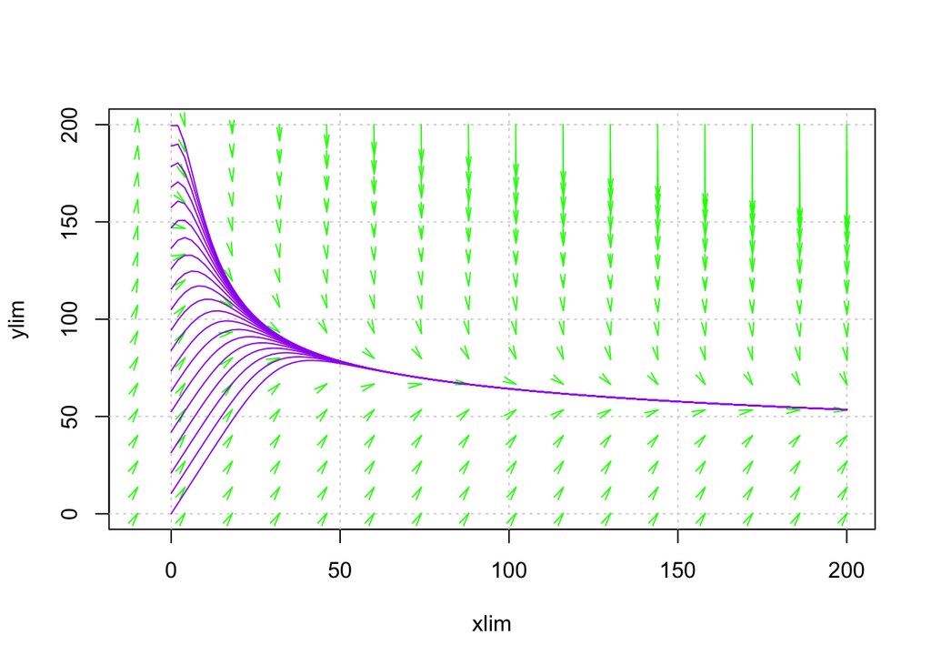